# Phylogenetic Comparative Analysis Package and Vignette

```r
pat <- pcms_AlignAA(fast_file)
pat # prints the MUSCLE alignment
```

```
## MUSCLE 3.8.31
##
## Call:
##    msa::msa(., method = c("Muscle"), type = "protein", order = c("aligned",     "input"))
##
## MsaAAMultipleAlignment with 25 rows and 928 columns
##      aln                                                   names
##  [1] -------------------------...------------------------- Mustela_putorius_...
##  [2] -------------------------...------------------------- Mustela_erminea_Shh
##  [3] -------------------------...------------------------- Enhydra_lutris_ke...
##  [4] -------------------------...------------------------- Lontra_canadensis...
##  [5] -------------------------...------------------------- Hyaena_hyaena_Shh
##  [6] -------------------------...------------------------- Ailuropoda_melano...
##  [7] -------------------------...------------------------- Suricata_suricatt...
##  [8] -------------------------...------------------------- Acinonyx_jubatus_...
##  [9] MDSYDGSVMSLDKANSGLPPPDTAA...------------------------- Felis_catus_Shh
##  ... ...
## [18] -------------------------...------------------------- Callorhinus_ursin...
## [19] -------------------------...------------------------- Leptonychotes_wed...
## [20] -------------------------...------------------------- Odobenus_rosmarus...
## [21] -------------------------...------------------------- Eumetopias_jubatu...
## [22] -------------------------...------------------------- Zalophus_californ...
## [23] -------------------------...------------------------- Vulpes_lagopus_Shh
## [24] -------------------------...------------------------- Neomonachus_schau...
## [25] -------------------------...------------------------- Mirounga_leonina_Shh
##  Con -------------------------...------------------------- Consensus
```

```r
class(pat) # "MsaAAMultipleAlignment"
```

```
## [1] "MsaAAMultipleAlignment"
## attr(,"package")
## [1] "msa"
```

## Running PCMs

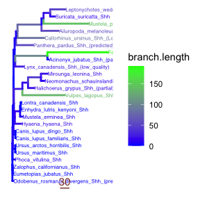

```r
ptree <- pcms_treeAA(pat)
ptree
```

```r
class(ptree)
```

```
## [1] "ggtree" "gg"     "ggplot"
```

## Plotting PCMs

**Plotting Neighbor Joining with ggtree**

[figure not shown]

```r
ggt <-ggtree(tree, cex = 0.8, aes(color = branch.length)) +
  scale_color_continuous(high='green',low='blue') +
  geom_tiplab(align = FALSE, size = 4) +
  geom_treescale(y = - 5, color = "coral4", fontsize = 2)
ggt
```

[figure not shown]

```r
pt <- plot_Tree(tree) # explain function (J)
```

## References

Bodenhofer, U., Bonatesta, E., Horejš-Kainrath, C., & Hochreiter, S. (2015). Msa: An r package for multiple sequence alignment. *Bioinformatics*, btv494. https://doi.org/10.1093/bioinformatics/btv494.

Pennell, M. W., & Harmon, L. J. (2013). An integrative view of phylogenetic comparative methods: Connections to population genetics, community ecology, and paleobiology: Integrative comparative methods. *Annals of the New York Academy of Sciences, 1289*(1), 90–105. https://doi.org/10.1111/nyas.12157

Toparslan, E., Karabag, K., & Bilge, U. (2020). A workflow with R: Phylogenetic analyses and visualizations using mitochondrial cytochrome b gene sequences. *PLOS ONE, 15*(12), e0243927. https://doi.org/10.1371/journal.pone.0243927

Yu, G., Smith, D. K., Zhu, H., Guan, Y., & Lam, T. T. (2017). ggtree: An r package for visualization and annotation of phylogenetic trees with their covariates and other associated data. *Methods in Ecology and Evolution, 8*(1), 28–36. https://doi.org/10.1111/2041-210X.12628